# Colorectal Cancer: Marker Genes Expression Analysis

- Show All Code
- Hide All Code
- View Source

Author

CBL Students | Ana Carolina Fernandes & Nuno Aguileira & Vitoria Correia

Published

July 2, 2026

# Clinical Background

In clinical practice, diagnostic laboratories routinely offer genetic testing on panels of genes associated with specific diseases. For colorectal cancer, two clinically validated gene panels are used in diagnostic settings in Portugal, as defined by the [Germano de Sousa](https://genetica.germanodesousa.com) genetics laboratory:

**Hereditary Colon Cancer Panel (19 genes)** ([source](https://genetica.germanodesousa.com/analises/4002/)) — used to identify germline mutations associated with hereditary colorectal cancer syndromes such as Lynch syndrome and familial adenomatous polyposis. The genes included are: APC, BMPR1A, MLH1, MSH2, MSH6, PMS2, EPCAM, MUTYH, PTEN, STK11, SMAD4, TP53, GREM1, POLD1, POLE, AXIN2, NTHL1, MSH3, and CHEK2.

**Somatic Colon Panel — Liquid or Tissue Biopsy (5 genes)** ([liquid biopsy source](https://genetica.germanodesousa.com/analises/4433/) | [tissue biopsy source](https://genetica.germanodesousa.com/analises/4434/)) — used to identify somatic mutational hotspots in tumour tissue or liquid biopsy samples, with implications for targeted therapy selection. The genes included are: KRAS, NRAS, BRAF, PIK3CA, and AKT1.

Here we analyse the TPM expression levels of these clinically relevant marker genes across cancer and healthy samples, to assess whether their transcriptional profiles differ between the two groups.

# Data and Marker Genes Setup

```r
library(here)
library(dplyr)
library(stringr)
library(ggplot2)
library(ggh4x)
library(ggtext)

# Load data
tpm <- readRDS(here::here("data/processed/merged/tpm.rds"))
normalised_counts <- readRDS(here::here("data/processed/normalised_counts.rds"))
de_results <- readr::read_rds(here::here("data/processed/de_results.rds"))

# Define marker genes and their clinical panel
marker_genes <- data.frame(
  gene_symbol = c("APC", "BMPR1A", "MLH1", "MSH2", "MSH6", "PMS2", "EPCAM", "MUTYH", "PTEN", "STK11",
                  "SMAD4", "TP53", "GREM1", "POLD1", "POLE", "AXIN2", "NTHL1", "MSH3", "CHEK2", "KRAS",
                  "NRAS", "BRAF", "PIK3CA", "AKT1"),
  panel = c(
    rep("Hereditary Colon Cancer", 19),
    rep("Somatic Colon Panel, Liquid or Tissue Biopsy", 5)
  )
)

# Add ENSEMBL gene IDs by joining with normalised counts annotations
marker_genes <- marker_genes |>
  dplyr::left_join(
    dplyr::select(normalised_counts, gene_id, gene_symbol),
    by = "gene_symbol"
  ) |>
  dplyr::relocate(gene_id, .before = panel)

# Remove Ensembl version suffixes from TPM gene IDs to allow joining with marker genes
tpm <- tpm |>
  dplyr::mutate(gene_id = stringr::str_remove(gene_id, "\\.\\d+$"))

# Extract shrunk log2 fold changes and adjusted p-values from DESeq2 results
de_stats <- de_results$shrunk |>
  tibble::as_tibble(rownames = "gene_id") |>
  dplyr::select(gene_id, log2FoldChange, padj)

# Join DE stats to a temporary object to avoid overwriting marker_genes across re-renders
marker_genes_de <- marker_genes |>
  dplyr::mutate(gene_id = stringr::str_remove(gene_id, "\\.\\d+$")) |>
  dplyr::left_join(de_stats, by = "gene_id") |>
  dplyr::mutate(
    padj_label = dplyr::case_when(
      is.na(padj) ~ "Not tested",
      padj == 0   ~ "padj ≈ 0",
      TRUE        ~ paste0("padj = ", signif(padj, 3))
    ),
    sig_star = dplyr::if_else(!is.na(padj) & padj < 0.05, "*", ""),
    # Build strip label: gene symbol + significance star + padj
    strip_label = paste0(gene_symbol, sig_star, "\n", padj_label)
  )

# Create a color mapping per gene based on clinical panel
strip_colors <- marker_genes_de |>
  dplyr::select(strip_label, panel) |>
  dplyr::mutate(color = dplyr::case_when(
    panel == "Hereditary Colon Cancer" ~ "#a8dadc",
    panel == "Somatic Colon Panel, Liquid or Tissue Biopsy" ~ "#f4a261"
  ))

# Preserve original gene order
strip_label_levels <- marker_genes_de$strip_label

# Create custom colored strip backgrounds using ggh4x + ggtext for markdown rendering
custom_strip <- ggh4x::strip_themed(
  background_x = ggh4x::elem_list_rect(fill = strip_colors$color),
  text_x       = ggh4x::elem_list_text(colour = rep("black", nrow(strip_colors)))
)
```

# TPM Expression | Cancer vs Healthy

TPM (Transcripts Per Million) is a normalization method for RNA-seq data that accounts for both gene length and sequencing depth, making it suitable for comparing expression levels across samples. The boxplots below show the TPM distribution for each marker gene in cancer and healthy samples, with the strip background colored according to the clinical panel of origin. Each strip also displays the differential expression status and adjusted p-value (Benjamini-Hochberg FDR) for that gene, as determined by DESeq2.

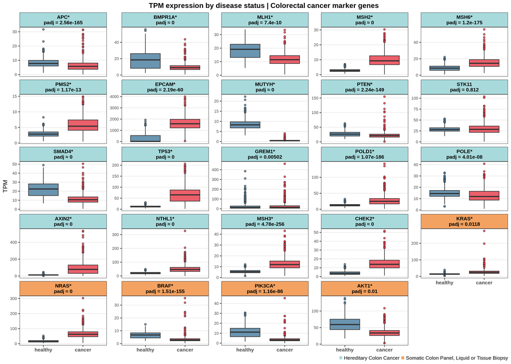

```r
# Build boxplot of TPM expression for marker genes, faceted by strip_label
marker_genes_boxplot <- tpm |>
  dplyr::filter(gene_id %in% marker_genes_de$gene_id) |>
  dplyr::left_join(dplyr::select(marker_genes_de, gene_id, strip_label, panel), by = "gene_id") |>
  dplyr::mutate(
    strip_label    = factor(strip_label, levels = strip_label_levels),
    disease_status = factor(disease_status, levels = c("healthy", "cancer"))
  ) |>
  ggplot2::ggplot(ggplot2::aes(x = disease_status, y = tpm, fill = disease_status)) +
  ggplot2::geom_boxplot(outlier.shape = 21, outlier.size = 1.5, alpha = 0.8) +
  ggh4x::facet_wrap2(~ strip_label, scales = "free_y", strip = custom_strip) +
  ggplot2::scale_fill_manual(values = c("cancer" = "#E63946", "healthy" = "#457B9D")) +
  ggplot2::theme_bw(base_size = 12) +
  ggplot2::labs(
    title   = "TPM expression by disease status | Colorectal cancer marker genes",
    x       = NULL,
    y       = "TPM",
    caption = "<span style='color:#a8dadc;font-size:16px'>■</span> Hereditary Colon Cancer &nbsp;&nbsp;
    <span style='color:#f4a261;font-size:16px'>■</span> Somatic Colon Panel, Liquid or Tissue Biopsy"
  ) +
  ggplot2::theme(
    legend.position    = "none",
    strip.text         = ggplot2::element_text(
                           face   = "bold",
                           size   = 10,
                           hjust  = 0.5,
                           colour = "black"
                         ),
    axis.text.x        = ggplot2::element_text(size = 10, face = "bold"),
    axis.text.y        = ggplot2::element_text(size = 8),
    panel.grid.minor   = ggplot2::element_blank(),
    panel.grid.major.x = ggplot2::element_blank(),
    plot.title         = ggplot2::element_text(face = "bold", size = 14, hjust = 0.5),
    plot.caption       = ggtext::element_markdown(size = 10)
  )

marker_genes_boxplot
```